# Toronto Dwellings Analysis

In this assignment, you will perform fundamental analysis for the Toronto dwellings market to allow potential real estate investors to choose rental investment properties.

```python
# Imported the necesscary libraries for project

import panel as pn
pn.extension('plotly')

import plotly.express as px

import plotly

import pandas as pd

import hvplot.pandas

from matplotlib import pyplot as plt

import os

from pathlib import Path

from dotenv import load_dotenv

import numpy as np
```

```python
# Loaded .env environment variables

load_dotenv()

map_box_api = os.getenv("mapbox_akey")

px.set_mapbox_access_token(map_box_api)
```

## Load Data

```python
# Loaded the census data into a Pandas DataFrame

file_path = Path("Data/toronto_neighbourhoods_census_data.csv")

census_data = pd.read_csv(file_path, index_col="year")

census_data.head()
```

| year | neighbourhood | single_detached_house | apartment_five_storeys_plus | movable_dwelling | semi_detached_house | row_house | duplex | apartment_five_storeys_less | other_house | average_house_value | shelter_costs_owned | shelter_costs_rented |
| --- | --- | --- | --- | --- | --- | --- | --- | --- | --- | --- | --- | --- |
| 2001 | Agincourt North | 3715 | 1480 | 0 | 1055 | 1295 | 195 | 185 | 5 | 200388 | 810 | 870 |
| 2001 | Agincourt South-Malvern West | 3250 | 1835 | 0 | 545 | 455 | 105 | 425 | 0 | 203047 | 806 | 892 |
| 2001 | Alderwood | 3175 | 315 | 0 | 470 | 50 | 185 | 370 | 0 | 259998 | 817 | 924 |
| 2001 | Annex | 1060 | 6090 | 5 | 1980 | 605 | 275 | 3710 | 165 | 453850 | 1027 | 1378 |
| 2001 | Banbury-Don Mills | 3615 | 4465 | 0 | 240 | 380 | 15 | 1360 | 0 | 371864 | 1007 | 1163 |

## Dwelling Types Per Year

In this section, you will calculate the number of dwelling types per year. Visualize the results using bar charts and the Pandas plot function.

**Hint:** Use the Pandas `groupby` function.

**Optional challenge:** Plot each bar chart in a different color.

```python
# Calculated the sum number of dwelling types units per year using groupby function

dwelling_df = census_data[["neighbourhood", "single_detached_house", "apartment_five_storeys_plus", "movable_dwelling", "semi_detached_house", "row_house", "duplex", "apartment_five_storeys_less", "other_house"]].groupby("year").sum()

dwelling_df
```

| year | single_detached_house | apartment_five_storeys_plus | movable_dwelling | semi_detached_house | row_house | duplex | apartment_five_storeys_less | other_house |
| --- | --- | --- | --- | --- | --- | --- | --- | --- |
| 2001 | 300930 | 355015 | 75 | 90995 | 52355 | 23785 | 116900 | 3040 |
| 2006 | 266860 | 379400 | 165 | 69430 | 54690 | 44095 | 162850 | 1335 |
| 2011 | 274940 | 429220 | 100 | 72480 | 60355 | 44750 | 163895 | 2165 |
| 2016 | 269680 | 493270 | 95 | 71200 | 61565 | 48585 | 165575 | 2845 |

```python
# Saved the dataframe as a csv file

dwelling_df.to_csv("dwelling.csv")
```

```python
# Extracted data for each from "dwelling_df"

year_2001 = pd.DataFrame(dwelling_df.iloc[0,:])

year_2001.rename(columns={2001:'dwelling_number'}, inplace=True)

year_2006 = pd.DataFrame(dwelling_df.iloc[1,:])

year_2006.rename(columns={2006:'dwelling_number'}, inplace=True)

year_2011 = pd.DataFrame(dwelling_df.iloc[2,:])

year_2011.rename(columns={2011:'dwelling_number'}, inplace=True)

year_2016 = pd.DataFrame(dwelling_df.iloc[3,:])

year_2016.rename(columns={2016:'dwelling_number'}, inplace=True)
```

```python
# Created bar_chart function

def bar_chart(data, title, xlabel, ylabel, color):
    plt.bar(x=data.index, height=data.dwelling_number, color=color, width = 0.6)
    plt.title(title,fontweight='bold')
    plt.xlabel(xlabel)
    plt.ylabel(ylabel)
    plt.xticks(rotation=90)
```

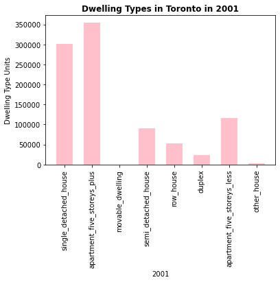

```python
# Createed a bar chart per year to show the number of dwelling types

# Bar chart for 2001

bar_chart(year_2001, 'Dwelling Types in Toronto in 2001', '2001', 'Dwelling Type Units', 'pink')
```

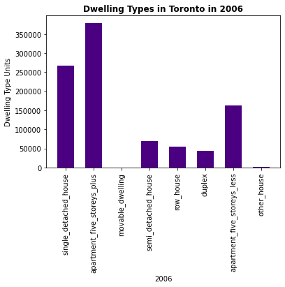

```python
# Bar chart for 2006

bar_chart(year_2006, 'Dwelling Types in Toronto in 2006', '2006', 'Dwelling Type Units', 'indigo')
```

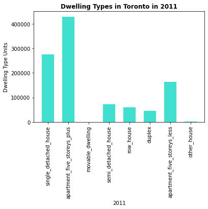

```python
# Bar chart for 2011

bar_chart(year_2011, 'Dwelling Types in Toronto in 2011', '2011', 'Dwelling Type Units', 'turquoise')
```

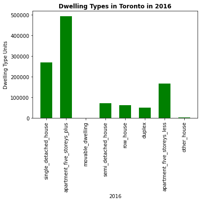

```python
# Bar chart for 2016

bar_chart(year_2016, 'Dwelling Types in Toronto in 2016', '2016', 'Dwelling Type Units', 'green')
```

## Average Monthly Shelter Costs in Toronto Per Year

In this section, you will calculate the average monthly shelter costs for owned and rented dwellings and the average house value for each year. Plot the results as a line chart.

**Optional challenge:** Plot each line chart in a different color.

```python
# Calculated the average monthly shelter costs for owned and rented dwellings

shelter_avg_costs = census_data[['shelter_costs_owned', 'shelter_costs_rented']].groupby(census_data.index).mean()

shelter_avg_costs
```

| year | shelter_costs_owned | shelter_costs_rented |
| --- | --- | --- |
| 2001 | 846.878571 | 1085.935714 |
| 2006 | 1316.800000 | 925.414286 |
| 2011 | 1448.214286 | 1019.792857 |
| 2016 | 1761.314286 | 1256.321429 |

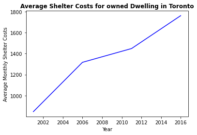

```python
# Created line_chart function

def line_chart(data, title, xlabel, ylabel, color):
    plt.plot(data, color=color)
    plt.xlabel(xlabel)
    plt.ylabel(ylabel)
    plt.title(title, fontweight='bold')

# Plotted line chart for owned dwellings

line_chart(shelter_avg_costs['shelter_costs_owned'],'Average Shelter Costs for owned Dwelling in Toronto', 'Year', 'Average Monthly Shelter Costs', 'Blue')
```

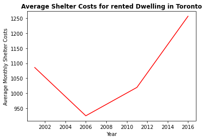

```python
# Plotted line chart for rented dwellings

line_chart(shelter_avg_costs['shelter_costs_rented'], 'Average Shelter Costs for rented Dwelling in Toronto', 'Year', 'Average Monthly Shelter Costs', 'Red')
```

## Average House Value per Year

```python
# Calculate the average house value per year

avg_hour_value = census_data[['average_house_value']].groupby(census_data.index).mean()

avg_hour_value
```

| year | average_house_value |
| --- | --- |
| 2001 | 289882.885714 |
| 2006 | 424059.664286 |
| 2011 | 530424.721429 |
| 2016 | 664068.328571 |

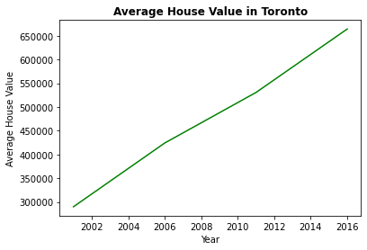

```python
# Plotted the average house value per year as a line chart

line_chart(avg_hour_value, 'Average House Value in Toronto', 'Year', 'Average House Value', 'Green')
```

## Average House Value by Neighbourhood

In this section, you will use `hvplot` to create an interactive visualization of the average house value with a dropdown selector for the neighbourhood.

**Hint:** It will be easier to create a new DataFrame from grouping the data and calculating the mean house values for each year and neighbourhood.

```python
# Created a new DataFrame with the mean house values by neighbourhood per year

avg_by_neighbourhood = census_data[['neighbourhood','average_house_value']].groupby([census_data.index,"neighbourhood"]).mean().reset_index()

avg_by_neighbourhood.set_index('year', inplace=True)

avg_by_neighbourhood[:10]
```

| year | neighbourhood | average_house_value |
| --- | --- | --- |
| 2001 | Agincourt North | 200388 |
| 2001 | Agincourt South-Malvern West | 203047 |
| 2001 | Alderwood | 259998 |
| 2001 | Annex | 453850 |
| 2001 | Banbury-Don Mills | 371864 |
| 2001 | Bathurst Manor | 304749 |
| 2001 | Bay Street Corridor | 257404 |
| 2001 | Bayview Village | 327644 |
| 2001 | Bayview Woods-Steeles | 343535 |
| 2001 | Bedford Park-Nortown | 565304 |

```python
# Created an interactive line chart of the average house value per neighbourhood using hvplot. Plot has a dropdown feature to select neighbourhood.

avg_by_neighbourhood.hvplot(groupby='neighbourhood', xlabel='Year', ylabel='Avg House Value').opts(yformatter="%.0f")
```

[interactive chart not shown]

## Number of Dwelling Types per Year

In this section, you will use `hvplot` to create an interactive visualization of the average number of dwelling types per year with a dropdown selector for the neighbourhood.

```python
# Fetched the data of all dwelling types per year

number_dwelling_per_year = census_data[["neighbourhood",'single_detached_house','apartment_five_storeys_plus','movable_dwelling','semi_detached_house','row_house','duplex','apartment_five_storeys_less','other_house']].groupby([census_data.index,"neighbourhood"]).sum().reset_index()

number_dwelling_per_year.set_index("year", inplace=True)

number_dwelling_per_year[:5]
```

| year | neighbourhood | single_detached_house | apartment_five_storeys_plus | movable_dwelling | semi_detached_house | row_house | duplex | apartment_five_storeys_less | other_house |
| --- | --- | --- | --- | --- | --- | --- | --- | --- | --- |
| 2001 | Agincourt North | 3715 | 1480 | 0 | 1055 | 1295 | 195 | 185 | 5 |
| 2001 | Agincourt South-Malvern West | 3250 | 1835 | 0 | 545 | 455 | 105 | 425 | 0 |
| 2001 | Alderwood | 3175 | 315 | 0 | 470 | 50 | 185 | 370 | 0 |
| 2001 | Annex | 1060 | 6090 | 5 | 1980 | 605 | 275 | 3710 | 165 |
| 2001 | Banbury-Don Mills | 3615 | 4465 | 0 | 240 | 380 | 15 | 1360 | 0 |

```python
# Created an interactive line chart of the number of dwelling types per neighbourhood using hvplot. Plot has a dropdown feature to select neighbourhood.

number_dwelling_per_year.hvplot.bar(groupby="neighbourhood", rot=90,width=650, height=500,xlabel='Year', ylabel='Dwelling Types Units')
```

[interactive chart not shown]

## The Top 10 Most Expensive Neighbourhoods

In this section, you will need to calculate the house value for each neighbourhood and then sort the values to obtain the top 10 most expensive neighbourhoods on average. Plot the results as a bar chart.

```python
# Fetched data from the top 10 expensive neighbourhoods

expensive_house = census_data[["neighbourhood",'single_detached_house','apartment_five_storeys_plus','movable_dwelling','semi_detached_house','row_house','duplex','apartment_five_storeys_less','other_house',"average_house_value","shelter_costs_owned","shelter_costs_rented"]].groupby("neighbourhood").mean().sort_values(by='average_house_value',ascending=False)

expensive_house = expensive_house[:10]

# Initialized Data

expensive_house.reset_index(inplace=True)

expensive_house
```

|  | neighbourhood | single_detached_house | apartment_five_storeys_plus | movable_dwelling | semi_detached_house | row_house | duplex | apartment_five_storeys_less | other_house | average_house_value | shelter_costs_owned | shelter_costs_rented |
| --- | --- | --- | --- | --- | --- | --- | --- | --- | --- | --- | --- | --- |
| 0 | Bridle Path-Sunnybrook-York Mills | 2260.00 | 331.25 | 0.00 | 36.25 | 90.00 | 25.0 | 40.00 | 0.00 | 1526485.75 | 2360.75 | 2321.75 |
| 1 | Forest Hill South | 1742.50 | 2031.25 | 1.25 | 61.25 | 45.00 | 75.0 | 1027.50 | 3.75 | 1195992.50 | 1781.00 | 1313.75 |
| 2 | Lawrence Park South | 3472.50 | 773.75 | 0.00 | 126.25 | 38.75 | 225.0 | 966.25 | 16.25 | 1094027.75 | 1954.00 | 1372.75 |
| 3 | Rosedale-Moore Park | 2498.75 | 4641.25 | 0.00 | 486.25 | 245.00 | 327.5 | 1618.75 | 2.50 | 1093640.00 | 1909.75 | 1537.25 |
| 4 | St.Andrew-Windfields | 3225.00 | 1670.00 | 0.00 | 185.00 | 552.50 | 97.5 | 586.25 | 5.00 | 999107.00 | 1880.25 | 1384.50 |
| 5 | Casa Loma | 916.25 | 2310.00 | 0.00 | 288.75 | 201.25 | 162.5 | 1192.50 | 2.50 | 981064.25 | 1873.75 | 1547.75 |
| 6 | Bedford Park-Nortown | 4865.00 | 1981.25 | 0.00 | 43.75 | 57.50 | 287.5 | 1275.00 | 88.75 | 930415.25 | 1786.75 | 1255.00 |
| 7 | Forest Hill North | 1488.75 | 3392.50 | 0.00 | 12.50 | 16.25 | 82.5 | 402.50 | 1.25 | 851680.50 | 1722.75 | 1245.50 |
| 8 | Kingsway South | 2326.25 | 576.25 | 0.00 | 66.25 | 48.75 | 20.0 | 336.25 | 2.50 | 843234.25 | 1736.75 | 1622.00 |
| 9 | Yonge-St.Clair | 565.00 | 3948.75 | 0.00 | 425.00 | 212.50 | 172.5 | 1308.75 | 6.25 | 813220.25 | 1680.75 | 1369.00 |

```python
# Plotted the data from the top 10 expensive neighbourhoods

expensive_house.hvplot.bar(x='neighbourhood', y='average_house_value', rot=90, height=500,title='Top10 Expensive Neighbourhoods in Toronto', xlabel='Neighbourhood', ylabel='Avg House Value')
```

[interactive chart not shown]

## Neighbourhood Map

In this section, you will read in neighbourhoods location data and build an interactive map with the average house value per neighbourhood. Use a `scatter_mapbox` from Plotly express to create the visualization. Remember, you will need your Mapbox API key for this.

### Load Location Data

```python
# Load neighbourhoods coordinates data
file_path = Path("Data/toronto_neighbourhoods_coordinates.csv")

df_neighbourhood_locations = pd.read_csv(file_path)

df_neighbourhood_locations.head()
```

|  | neighbourhood | lat | lon |
| --- | --- | --- | --- |
| 0 | Agincourt North | 43.805441 | -79.266712 |
| 1 | Agincourt South-Malvern West | 43.788658 | -79.265612 |
| 2 | Alderwood | 43.604937 | -79.541611 |
| 3 | Annex | 43.671585 | -79.404001 |
| 4 | Banbury-Don Mills | 43.737657 | -79.349718 |

### Data Preparation

You will need to join the location data with the mean values per neighbourhood.

1. Calculate the mean values for each neighbourhood.
2. Join the average values with the neighbourhood locations.

```python
# Calculated the mean values for each neighborhood

mean_neighborhood =  census_data[['neighbourhood','single_detached_house','apartment_five_storeys_plus','movable_dwelling','semi_detached_house','row_house','duplex','apartment_five_storeys_less','other_house',"average_house_value","shelter_costs_owned","shelter_costs_rented"]].groupby("neighbourhood").mean().reset_index()

mean_neighborhood.head()
```

|  | neighbourhood | single_detached_house | apartment_five_storeys_plus | movable_dwelling | semi_detached_house | row_house | duplex | apartment_five_storeys_less | other_house | average_house_value | shelter_costs_owned | shelter_costs_rented |
| --- | --- | --- | --- | --- | --- | --- | --- | --- | --- | --- | --- | --- |
| 0 | Agincourt North | 3435.00 | 1947.50 | 2.50 | 863.75 | 1406.25 | 512.50 | 547.50 | 10.00 | 329811.5 | 1109.00 | 983.50 |
| 1 | Agincourt South-Malvern West | 2897.50 | 2180.00 | 1.25 | 375.00 | 456.25 | 523.75 | 628.75 | 32.50 | 334189.0 | 1131.25 | 985.00 |
| 2 | Alderwood | 2903.75 | 302.50 | 1.25 | 503.75 | 76.25 | 302.50 | 502.50 | 1.25 | 427922.5 | 1166.75 | 1003.25 |
| 3 | Annex | 751.25 | 7235.00 | 1.25 | 1375.00 | 613.75 | 355.00 | 4605.00 | 83.75 | 746977.0 | 1692.75 | 1315.25 |
| 4 | Banbury-Don Mills | 3572.50 | 5388.75 | 1.25 | 273.75 | 626.25 | 32.50 | 1340.00 | 0.00 | 612039.0 | 1463.50 | 1242.75 |

```python
# Joined the average values with the neighbourhood locations

combined_df = pd.concat([df_neighbourhood_locations.set_index('neighbourhood'),mean_neighborhood.set_index('neighbourhood')], axis=1, join='inner').reset_index()

combined_df.head()

combined_df.reset_index(inplace=True)
```

### Mapbox Visualization

Plot the average values per neighbourhood using a Plotly express `scatter_mapbox` visualization.

```python
# Created a scatter mapbox to analyze neighbourhood info

map_1 = px.scatter_mapbox(
    combined_df,
    lat="lat",
    lon="lon",
    color="average_house_value",
    size="average_house_value",
    color_continuous_scale=px.colors.sequential.Cividis,
    zoom = 10
)

map_1.show()
```

[output not shown]

## Cost Analysis - Optional Challenge

In this section, you will use Plotly express to a couple of plots that investors can interactively filter and explore various factors related to the house value of the Toronto's neighbourhoods.

### Create a bar chart row facet to plot the average house values for all Toronto's neighbourhoods per year

```python
# Recalled and checked dataframe "avg_by_neighbourhood"

avg_by_neighbourhood.head()
```

| year | neighbourhood | average_house_value |
| --- | --- | --- |
| 2001 | Agincourt North | 200388 |
| 2001 | Agincourt South-Malvern West | 203047 |
| 2001 | Alderwood | 259998 |
| 2001 | Annex | 453850 |
| 2001 | Banbury-Don Mills | 371864 |

```python
# Created a bar chart row facet to plot the average house values for all Toronto's neighbourhoods per year

px.bar(avg_by_neighbourhood,x='neighbourhood',y='average_house_value',facet_row=avg_by_neighbourhood.index,title='Average House Values in Toronto per Neighbourhood per year',height=1200, width=900, hover_data=['average_house_value'], color='average_house_value')
```

[output not shown]

### Create a sunburst chart to conduct a costs analysis of most expensive neighbourhoods in Toronto per year

```python
# Fetched the data from all expensive neighbourhoods per year.

costs_per_neighbourhood = census_data.filter(["neighbourhood","shelter_costs_owned","shelter_costs_rented"], axis =1)

costs_per_neighbourhood
```

| year | neighbourhood | shelter_costs_owned | shelter_costs_rented |
| --- | --- | --- | --- |
| 2001 | Agincourt North | 810 | 870 |
| 2001 | Agincourt South-Malvern West | 806 | 892 |
| 2001 | Alderwood | 817 | 924 |
| 2001 | Annex | 1027 | 1378 |
| 2001 | Banbury-Don Mills | 1007 | 1163 |
| ... | ... | ... | ... |
| 2016 | Wychwood | 1864 | 1146 |
| 2016 | Yonge-Eglinton | 2398 | 1535 |
| 2016 | Yonge-St.Clair | 2192 | 1619 |
| 2016 | York University Heights | 1444 | 1122 |
| 2016 | Yorkdale-Glen Park | 1451 | 1128 |

560 rows × 3 columns

```python
# Created a dataframe for top neighborhood

top_neighbourhood = expensive_house.reset_index()

top_neighbourhood = top_neighbourhood["neighbourhood"].tolist()

top_neighbourhood
```

```
['Bridle Path-Sunnybrook-York Mills',
 'Forest Hill South',
 'Lawrence Park South',
 'Rosedale-Moore Park',
 'St.Andrew-Windfields',
 'Casa Loma',
 'Bedford Park-Nortown',
 'Forest Hill North',
 'Kingsway South',
 'Yonge-St.Clair']
```

```python
# Initiated a query

top_neighbourhood_df = costs_per_neighbourhood.query("neighbourhood in @top_neighbourhood")

top_neighbourhood_df
```

| year | neighbourhood | shelter_costs_owned | shelter_costs_rented |
| --- | --- | --- | --- |
| 2001 | Bedford Park-Nortown | 933 | 1491 |
| 2001 | Bridle Path-Sunnybrook-York Mills | 1983 | 1790 |
| 2001 | Casa Loma | 1241 | 1500 |
| 2001 | Forest Hill North | 940 | 1428 |
| 2001 | Forest Hill South | 1001 | 1469 |
| 2001 | Kingsway South | 1362 | 1340 |
| 2001 | Lawrence Park South | 1021 | 1630 |
| 2001 | Rosedale-Moore Park | 1219 | 1540 |
| 2001 | St.Andrew-Windfields | 1055 | 1551 |
| 2001 | Yonge-St.Clair | 1091 | 1351 |
| 2006 | Bedford Park-Nortown | 1808 | 1020 |
| 2006 | Bridle Path-Sunnybrook-York Mills | 2170 | 2167 |
| 2006 | Casa Loma | 1819 | 1356 |
| 2006 | Forest Hill North | 1731 | 1027 |
| 2006 | Forest Hill South | 1781 | 1094 |
| 2006 | Kingsway South | 1625 | 1488 |
| 2006 | Lawrence Park South | 1977 | 1116 |
| 2006 | Rosedale-Moore Park | 1868 | 1332 |
| 2006 | St.Andrew-Windfields | 1881 | 1152 |
| 2006 | Yonge-St.Clair | 1638 | 1192 |
| 2011 | Bedford Park-Nortown | 1988 | 1124 |
| 2011 | Bridle Path-Sunnybrook-York Mills | 2387 | 2388 |
| 2011 | Casa Loma | 2001 | 1494 |
| 2011 | Forest Hill North | 1904 | 1132 |
| 2011 | Forest Hill South | 1959 | 1206 |
| 2011 | Kingsway South | 1787 | 1640 |
| 2011 | Lawrence Park South | 2174 | 1230 |
| 2011 | Rosedale-Moore Park | 2054 | 1468 |
| 2011 | St.Andrew-Windfields | 2069 | 1270 |
| 2011 | Yonge-St.Clair | 1802 | 1314 |
| 2016 | Bedford Park-Nortown | 2418 | 1385 |
| 2016 | Bridle Path-Sunnybrook-York Mills | 2903 | 2942 |
| 2016 | Casa Loma | 2434 | 1841 |
| 2016 | Forest Hill North | 2316 | 1395 |
| 2016 | Forest Hill South | 2383 | 1486 |
| 2016 | Kingsway South | 2173 | 2020 |
| 2016 | Lawrence Park South | 2644 | 1515 |
| 2016 | Rosedale-Moore Park | 2498 | 1809 |
| 2016 | St.Andrew-Windfields | 2516 | 1565 |
| 2016 | Yonge-St.Clair | 2192 | 1619 |

```python
# Prepared a new dataframe for sunburst chart called "df1"

df1 = top_neighbourhood_df.reset_index()

df1
```

|  | year | neighbourhood | shelter_costs_owned | shelter_costs_rented |
| --- | --- | --- | --- | --- |
| 0 | 2001 | Bedford Park-Nortown | 933 | 1491 |
| 1 | 2001 | Bridle Path-Sunnybrook-York Mills | 1983 | 1790 |
| 2 | 2001 | Casa Loma | 1241 | 1500 |
| 3 | 2001 | Forest Hill North | 940 | 1428 |
| 4 | 2001 | Forest Hill South | 1001 | 1469 |
| 5 | 2001 | Kingsway South | 1362 | 1340 |
| 6 | 2001 | Lawrence Park South | 1021 | 1630 |
| 7 | 2001 | Rosedale-Moore Park | 1219 | 1540 |
| 8 | 2001 | St.Andrew-Windfields | 1055 | 1551 |
| 9 | 2001 | Yonge-St.Clair | 1091 | 1351 |
| 10 | 2006 | Bedford Park-Nortown | 1808 | 1020 |
| 11 | 2006 | Bridle Path-Sunnybrook-York Mills | 2170 | 2167 |
| 12 | 2006 | Casa Loma | 1819 | 1356 |
| 13 | 2006 | Forest Hill North | 1731 | 1027 |
| 14 | 2006 | Forest Hill South | 1781 | 1094 |
| 15 | 2006 | Kingsway South | 1625 | 1488 |
| 16 | 2006 | Lawrence Park South | 1977 | 1116 |
| 17 | 2006 | Rosedale-Moore Park | 1868 | 1332 |
| 18 | 2006 | St.Andrew-Windfields | 1881 | 1152 |
| 19 | 2006 | Yonge-St.Clair | 1638 | 1192 |
| 20 | 2011 | Bedford Park-Nortown | 1988 | 1124 |
| 21 | 2011 | Bridle Path-Sunnybrook-York Mills | 2387 | 2388 |
| 22 | 2011 | Casa Loma | 2001 | 1494 |
| 23 | 2011 | Forest Hill North | 1904 | 1132 |
| 24 | 2011 | Forest Hill South | 1959 | 1206 |
| 25 | 2011 | Kingsway South | 1787 | 1640 |
| 26 | 2011 | Lawrence Park South | 2174 | 1230 |
| 27 | 2011 | Rosedale-Moore Park | 2054 | 1468 |
| 28 | 2011 | St.Andrew-Windfields | 2069 | 1270 |
| 29 | 2011 | Yonge-St.Clair | 1802 | 1314 |
| 30 | 2016 | Bedford Park-Nortown | 2418 | 1385 |
| 31 | 2016 | Bridle Path-Sunnybrook-York Mills | 2903 | 2942 |
| 32 | 2016 | Casa Loma | 2434 | 1841 |
| 33 | 2016 | Forest Hill North | 2316 | 1395 |
| 34 | 2016 | Forest Hill South | 2383 | 1486 |
| 35 | 2016 | Kingsway South | 2173 | 2020 |
| 36 | 2016 | Lawrence Park South | 2644 | 1515 |
| 37 | 2016 | Rosedale-Moore Park | 2498 | 1809 |
| 38 | 2016 | St.Andrew-Windfields | 2516 | 1565 |
| 39 | 2016 | Yonge-St.Clair | 2192 | 1619 |

```python
# Stored values of the df1 in seperate variables

year = df1['year']

neighbourhood = df1['neighbourhood']

shelter_costs_owned = df1['shelter_costs_owned']

shelter_costs_rented = df1['shelter_costs_rented']
```

```python
# Created a chart and store variables inside fig

fig = px.sunburst(df1,
               path=[year, neighbourhood],
               values=shelter_costs_owned,
               color=shelter_costs_owned,
               hover_data=[shelter_costs_rented],
               color_continuous_scale=['red', 'yellow', 'green'],
               title='Costs Analysis of Most Expensive Neighbourhood in Toronto per Year'
)
```

```python
# Initialized sunburst

fig.show()
```

[output not shown]